# EDA_Outage

## 10) Duration-Focused County-Year Exploration

The earlier duration models relied mainly on county-year mean duration and produced relatively weak results. This section explores more interpretable duration outcomes based on deduplicated outage events within each county-year, including median duration, p90 duration, and the share of long outages.

|  | county_fips | year | outage_occurrence | duration_mean | duration_median | duration_p90 | long_share_8h | long_share_24h | severe_weather_share | severe_weather_count | ... | cvi_climate_all_mean | cvi_climate_extreme_events_mean | high_cvi_share | z_severe_weather_share | z_severe_weather_count | z_log_outage_mean_customers_mean | z_cvi_overall_mean | z_cvi_baseline_social_econ_mean | z_cvi_climate_extreme_events_mean | z_high_cvi_share |
| --- | --- | --- | --- | --- | --- | --- | --- | --- | --- | --- | --- | --- | --- | --- | --- | --- | --- | --- | --- | --- | --- |
| 0 | 36005 | 2014 | 6 | 1.125000 | 1.25 | 1.625 | 0.000000 | 0.000000 | 0.000000 | 0 | ... | 0.435858 | 0.370434 | 0.743363 | -0.424775 | -0.722029 | -0.721270 | 1.565495 | 1.715568 | -0.671645 | 1.859233 |
| 1 | 36005 | 2015 | 69 | 1.699275 | 1.00 | 4.050 | 0.000000 | 0.000000 | 0.000000 | 0 | ... | 0.435858 | 0.370434 | 0.743363 | -0.424775 | -0.722029 | 0.160257 | 1.565495 | 1.715568 | -0.671645 | 1.859233 |
| 2 | 36005 | 2016 | 76 | 2.171053 | 1.75 | 4.500 | 0.026316 | 0.000000 | 0.000000 | 0 | ... | 0.435858 | 0.370434 | 0.743363 | -0.424775 | -0.722029 | 0.128356 | 1.565495 | 1.715568 | -0.671645 | 1.859233 |
| 3 | 36005 | 2017 | 64 | 2.242188 | 1.75 | 4.000 | 0.015625 | 0.000000 | 0.000000 | 0 | ... | 0.435858 | 0.370434 | 0.743363 | -0.424775 | -0.722029 | -0.042130 | 1.565495 | 1.715568 | -0.671645 | 1.859233 |
| 4 | 36005 | 2018 | 105 | 4.040476 | 1.50 | 7.000 | 0.066667 | 0.009524 | 0.066667 | 7 | ... | 0.435858 | 0.370434 | 0.743363 | 1.115082 | 2.488071 | 1.141391 | 1.565495 | 1.715568 | -0.671645 | 1.859233 |

5 rows × 31 columns

|  | county_name | year | duration_median | duration_p90 | long_share_8h | long_share_24h | severe_weather_share |
| --- | --- | --- | --- | --- | --- | --- | --- |
| 0 | Bronx | 2014 | 1.25 | 1.625 | 0.000000 | 0.000000 | 0.000000 |
| 1 | Bronx | 2015 | 1.00 | 4.050 | 0.000000 | 0.000000 | 0.000000 |
| 2 | Bronx | 2016 | 1.75 | 4.500 | 0.026316 | 0.000000 | 0.000000 |
| 3 | Bronx | 2017 | 1.75 | 4.000 | 0.015625 | 0.000000 | 0.000000 |
| 4 | Bronx | 2018 | 1.50 | 7.000 | 0.066667 | 0.009524 | 0.066667 |
| 5 | Bronx | 2019 | 1.50 | 4.325 | 0.025641 | 0.000000 | 0.051282 |
| 6 | Bronx | 2020 | 2.00 | 13.200 | 0.133333 | 0.028571 | 0.028571 |
| 7 | Bronx | 2021 | 2.25 | 7.750 | 0.094340 | 0.028302 | 0.000000 |
| 8 | Bronx | 2022 | 1.25 | 5.500 | 0.051613 | 0.000000 | 0.025806 |
| 9 | Bronx | 2023 | 1.50 | 4.000 | 0.029703 | 0.000000 | 0.009901 |

```
County-year rows with at least one outage event: 47
Unique outage events after deduplication: 4518
```

|  | label | outcome | nobs | r_squared | adj_r_squared | aic | year_coef | year_p | weather_coef | weather_p | weather_ci_low | weather_ci_high | customers_coef | customers_p | cvi_term | cvi_coef | cvi_p | cvi_sig_05 | weather_sig_05 |
| --- | --- | --- | --- | --- | --- | --- | --- | --- | --- | --- | --- | --- | --- | --- | --- | --- | --- | --- | --- |
| 2 | Median duration + climate CVI | log_duration_median | 47 | 0.240723 | 0.168411 | -0.283533 | -0.019429 | 0.119920 | 0.185296 | 0.001796 | 0.073133 | 0.297458 | -0.158360 | 0.008540 | z_cvi_climate_extreme_events_mean | 0.001690 | 0.964264 | False | True |
| 0 | Median duration + overall CVI | log_duration_median | 47 | 0.251109 | 0.179787 | -0.930905 | -0.019067 | 0.120890 | 0.172646 | 0.002526 | 0.064197 | 0.281094 | -0.146016 | 0.008580 | z_cvi_overall_mean | -0.026673 | 0.448803 | False | True |
| 1 | Median duration + social-economic CVI | log_duration_median | 47 | 0.242076 | 0.169892 | -0.367348 | -0.019439 | 0.116070 | 0.183454 | 0.001012 | 0.078685 | 0.288223 | -0.156795 | 0.003832 | z_cvi_baseline_social_econ_mean | -0.009313 | 0.782765 | False | True |
| 3 | P90 duration + social-economic CVI | log_duration_p90 | 47 | 0.283318 | 0.215062 | 63.086851 | -0.000966 | 0.967795 | 0.371155 | 0.000741 | 0.165376 | 0.576934 | -0.373119 | 0.000604 | z_cvi_baseline_social_econ_mean | 0.017031 | 0.797386 | False | True |
| 5 | Share > 24h + social-economic CVI | long_share_24h | 47 | 0.049820 | -0.040674 | -224.099967 | 0.000444 | 0.694365 | 0.002246 | 0.642530 | -0.007449 | 0.011941 | -0.005607 | 0.243426 | z_cvi_baseline_social_econ_mean | 0.000182 | 0.953499 | False | False |
| 4 | Share > 8h + social-economic CVI | long_share_8h | 47 | 0.251378 | 0.180081 | -124.011561 | -0.001470 | 0.653459 | 0.047531 | 0.001440 | 0.019414 | 0.075649 | -0.037517 | 0.009228 | z_cvi_baseline_social_econ_mean | -0.010881 | 0.233764 | False | True |

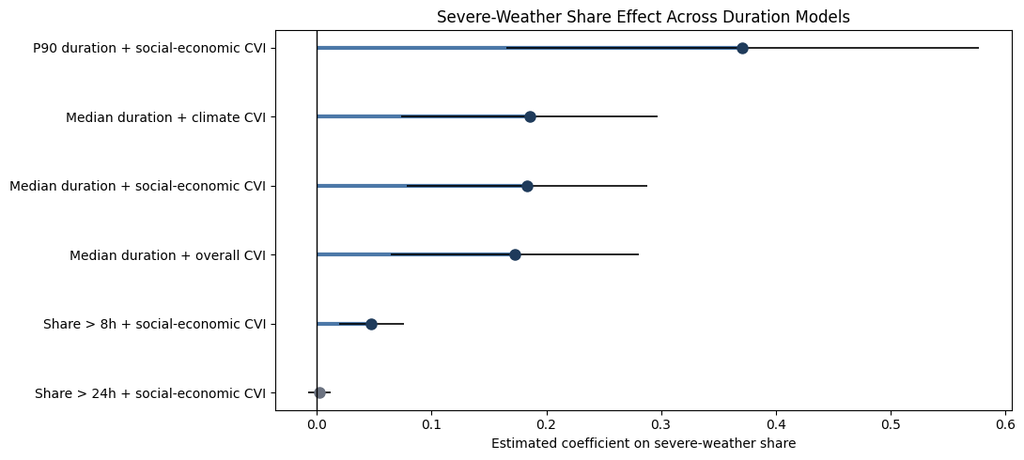

The duration analysis was refined by moving from county-year mean duration to event-level, deduplicated outage records and then constructing more interpretable county-year duration outcomes, including median duration, p90 duration, and the shares of outages lasting more than 8 or 24 hours. This produced a panel of 47 county-year observations based on 4,518 unique outage events. The descriptive results show that typical outage durations in NYC are generally short, with county-year median durations often around 1-2 hours, while the upper tail can be substantially longer; for example, in the Bronx the median duration ranged from 1.0 to 2.25 hours across 2014-2023, while the p90 duration ranged from 1.625 to 13.2 hours. The share of outages lasting more than 8 hours was usually modest but clearly nonzero in some years, reaching 0.133 in the Bronx in 2020, whereas the share above 24 hours was much smaller and often close to zero. Across the duration-focused regression models, the clearest and most consistent predictor was the severe-weather event share, which had a positive coefficient in every specification and was especially strong for upper-tail duration outcomes such as p90 duration. By contrast, county-level CVI variables were much weaker and less stable predictors of outage duration than they were for outage counts. Taken together, these results suggest that in the current dataset vulnerability is more clearly associated with how many outages occur, while outage duration appears to depend more directly on weather severity and the characteristics of the outage events themselves.